# Spotify音乐数据分析报告

**分析师**：董萱  
**日期**：2025.11.6  
**数据来源**：https://www.kaggle.com/datasets/maharshipandya/-spotify-tracks-dataset **分析工具**：Python, Pandas, Matplotlib, Seaborn

## 📋 执行摘要

本报告基于**114,000首Spotify歌曲**的音频特征数据，通过系统的数据分析揭示爆款歌曲的成功规律。分析涵盖流派趋势、音频特征相关性、聚类分析等多个维度，为音乐产业提供数据驱动的决策支持。

**核心价值**：

- 量化分析114种音乐流派的音频特征差异
- 识别高流行度流派的成功模式
- 为音乐内容策略和推荐系统提供数据洞察

**数据集特点**：平衡数据集设计，每个流派包含恰好1,000首歌曲，确保分析结果的公平性和可比性。

```python
# 第一步：基于实际列名调整代码
# 导入必要的库
import pandas as pd
import matplotlib.pyplot as plt
import seaborn as sns
import numpy as np
import plotly.express as px
from datetime import datetime

# 设置中文显示
plt.rcParams['font.sans-serif'] = ['SimHei']
plt.rcParams['axes.unicode_minus'] = False

print("库导入成功")
```

```
库导入成功
```

```python
# 读取Excel数据
file_path = r'C:\Users\dongx\Desktop\spotify_dataset.xlsx'
df = pd.read_excel(file_path)

# 查看数据基本信息
print("数据形状:", df.shape)
print("\n前5行数据:")
df.head()
```

```
数据形状: (114000, 21)

前5行数据:
```

|  | Unnamed: 0 | track_id | artists | album_name | track_name | popularity | duration_ms | explicit | danceability | energy | ... | loudness | mode | speechiness | acousticness | instrumentalness | liveness | valence | tempo | time_signature | track_genre |
| --- | --- | --- | --- | --- | --- | --- | --- | --- | --- | --- | --- | --- | --- | --- | --- | --- | --- | --- | --- | --- | --- |
| 0 | 0 | 5SuOikwiRyPMVoIQDJUgSV | Gen Hoshino | Comedy | Comedy | 73 | 230666 | False | 0.676 | 0.4610 | ... | -6.746 | 0 | 0.1430 | 0.0322 | 0.000001 | 0.3580 | 0.715 | 87.917 | 4 | acoustic |
| 1 | 1 | 4qPNDBW1i3p13qLCt0Ki3A | Ben Woodward | Ghost (Acoustic) | Ghost - Acoustic | 55 | 149610 | False | 0.420 | 0.1660 | ... | -17.235 | 1 | 0.0763 | 0.9240 | 0.000006 | 0.1010 | 0.267 | 77.489 | 4 | acoustic |
| 2 | 2 | 1iJBSr7s7jYXzM8EGcbK5b | Ingrid Michaelson;ZAYN | To Begin Again | To Begin Again | 57 | 210826 | False | 0.438 | 0.3590 | ... | -9.734 | 1 | 0.0557 | 0.2100 | 0.000000 | 0.1170 | 0.120 | 76.332 | 4 | acoustic |
| 3 | 3 | 6lfxq3CG4xtTiEg7opyCyx | Kina Grannis | Crazy Rich Asians (Original Motion Picture Sou... | Can't Help Falling In Love | 71 | 201933 | False | 0.266 | 0.0596 | ... | -18.515 | 1 | 0.0363 | 0.9050 | 0.000071 | 0.1320 | 0.143 | 181.740 | 3 | acoustic |
| 4 | 4 | 5vjLSffimiIP26QG5WcN2K | Chord Overstreet | Hold On | Hold On | 82 | 198853 | False | 0.618 | 0.4430 | ... | -9.681 | 1 | 0.0526 | 0.4690 | 0.000000 | 0.0829 | 0.167 | 119.949 | 4 | acoustic |

5 rows × 21 columns

## 📊 数据概览

### 数据集规模

- **总歌曲数量**：114,000首
- **音乐流派数量**：114种
- **艺术家数量**：31,436位
- **数据平衡性**：每个流派包含1,000首歌曲

### 流行度分布

- **爆款歌曲** (流行度>80)：954首 (0.8%)
- **热门歌曲** (流行度60-80)：12,616首 (11.1%)
- **一般歌曲** (流行度30-60)：48,674首 (42.7%)
- **冷门歌曲** (流行度<30)：35,736首 (31.4%)

### 音频特征统计

| 特征 | 平均值 | 标准差 | 范围 |
| --- | --- | --- | --- |
| 流行度 | 33.2 | 22.3 | 0-100 |
| 舞蹈性 | 0.567 | 0.174 | 0-0.985 |
| 能量 | 0.641 | 0.252 | 0-1.0 |
| 愉悦度 | 0.499 | 0.257 | 0-1.0 |
| 节奏 | 122.1 | 30.0 | 0-243.4 |

```python
# 数据清洗和准备
music_df = df.copy()

# 删除不必要的列
if 'Unnamed: 0' in music_df.columns:
    music_df = music_df.drop('Unnamed: 0', axis=1)

print("清理后的列名:", music_df.columns.tolist())

# 检查数据基本信息
print(f"\n数据总览:")
print(f"- 总歌曲数: {len(music_df):,}")
print(f"- 总艺术家数: {music_df['artists'].nunique()}")
print(f"- 总流派数: {music_df['track_genre'].nunique()}")
```

```
清理后的列名: ['track_id', 'artists', 'album_name', 'track_name', 'popularity', 'duration_ms', 'explicit', 'danceability', 'energy', 'key', 'loudness', 'mode', 'speechiness', 'acousticness', 'instrumentalness', 'liveness', 'valence', 'tempo', 'time_signature', 'track_genre']

数据总览:
- 总歌曲数: 114,000
- 总艺术家数: 31436
- 总流派数: 114
```

```python
# 检查数据质量
print("数据质量检查:")
print(music_df.isnull().sum())

# 基本统计信息
print("\n数值列统计:")
music_df[['popularity', 'duration_ms', 'danceability', 'energy', 'loudness', 'tempo']].describe()
```

```
数据质量检查:
track_id             0
artists             49
album_name          12
track_name           8
popularity           0
duration_ms          0
explicit             0
danceability         0
energy               0
key                  0
loudness             0
mode                 0
speechiness          0
acousticness         0
instrumentalness     0
liveness             0
valence              0
tempo                0
time_signature       0
track_genre          0
dtype: int64

数值列统计:
```

|  | popularity | duration_ms | danceability | energy | loudness | tempo |
| --- | --- | --- | --- | --- | --- | --- |
| count | 114000.000000 | 1.140000e+05 | 114000.000000 | 114000.000000 | 114000.000000 | 114000.000000 |
| mean | 33.238535 | 2.280292e+05 | 0.566800 | 0.641383 | -8.258960 | 122.147837 |
| std | 22.305078 | 1.072977e+05 | 0.173542 | 0.251529 | 5.029337 | 29.978197 |
| min | 0.000000 | 0.000000e+00 | 0.000000 | 0.000000 | -49.531000 | 0.000000 |
| 25% | 17.000000 | 1.740660e+05 | 0.456000 | 0.472000 | -10.013000 | 99.218750 |
| 50% | 35.000000 | 2.129060e+05 | 0.580000 | 0.685000 | -7.004000 | 122.017000 |
| 75% | 50.000000 | 2.615060e+05 | 0.695000 | 0.854000 | -5.003000 | 140.071000 |
| max | 100.000000 | 5.237295e+06 | 0.985000 | 1.000000 | 4.532000 | 243.372000 |

```python
# 第二步：创建流行度分类和数据分析
# 创建流行度分类
music_df['popularity_level'] = pd.cut(music_df['popularity'],
                                    bins=[0, 30, 60, 80, 100],
                                    labels=['冷门', '一般', '热门', '爆款'])

print("流行度分布:")
print(music_df['popularity_level'].value_counts())

# 主要流派分析
print(f"\n前10大音乐流派:")
top_genres = music_df['track_genre'].value_counts().head(10)
print(top_genres)
```

```
流行度分布:
一般    48674
冷门    35736
热门    12616
爆款      954
Name: popularity_level, dtype: int64

前10大音乐流派:
acoustic             1000
punk-rock            1000
progressive-house    1000
power-pop            1000
pop                  1000
pop-film             1000
piano                1000
party                1000
pagode               1000
opera                1000
Name: track_genre, dtype: int64
```

```python
# 重新查看流派分布情况
print("流派分布检查:")
print(f"总流派数量: {music_df['track_genre'].nunique()}")
print(f"每个流派的歌曲数量是否均匀: {music_df['track_genre'].value_counts().std() == 0}")

# 由于流派数量分布是人为平衡的，我们转而分析流派的平均流行度
print("\n🔍 调整分析重点: 由于数据集已平衡，我们将关注流派的平均流行度和特征差异")
```

```
流派分布检查:
总流派数量: 114
每个流派的歌曲数量是否均匀: True

🔍 调整分析重点: 由于数据集已平衡，我们将关注流派的平均流行度和特征差异
```

```
平均流行度最高的15个流派:
                   avg_popularity  song_count  avg_danceability  avg_energy  \
track_genre
pop-film                   59.283        1000             0.597       0.605
k-pop                      56.896        1000             0.648       0.676
chill                      53.651        1000             0.664       0.427
sad                        52.379        1000             0.692       0.462
grunge                     49.594        1000             0.457       0.803
indian                     49.539        1000             0.592       0.567
anime                      48.772        1000             0.537       0.674
emo                        48.128        1000             0.599       0.670
sertanejo                  47.866        1000             0.592       0.710
pop                        47.576        1000             0.630       0.606
progressive-house          46.615        1000             0.624       0.813
piano                      45.273        1000             0.455       0.320
mandopop                   45.025        1000             0.547       0.498
deep-house                 44.808        1000             0.710       0.742
brazil                     44.670        1000             0.563       0.621

                   avg_valence  avg_tempo
track_genre
pop-film                 0.529    117.257
k-pop                    0.557    119.244
chill                    0.404    115.479
sad                      0.422    119.065
grunge                   0.400    129.349
indian                   0.463    116.143
anime                    0.434    123.530
emo                      0.441    126.993
sertanejo                0.619    127.052
pop                      0.506    120.927
progressive-house        0.365    125.094
piano                    0.313    118.085
mandopop                 0.350    123.476
deep-house               0.447    120.875
brazil                   0.470    121.936
```

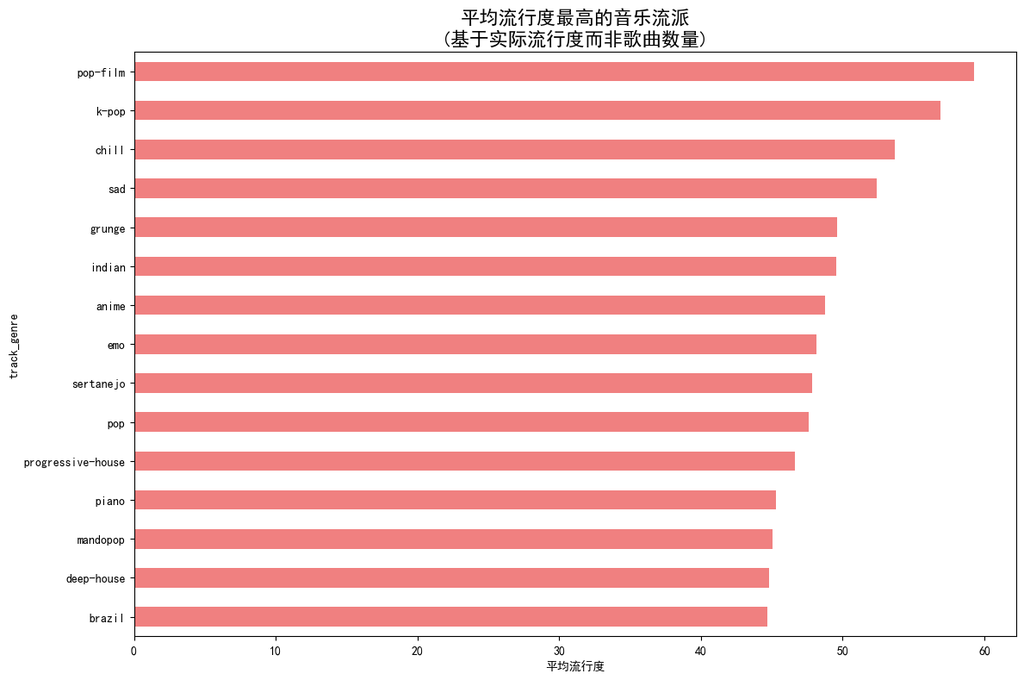

```python
# 第三步：针对性的可视化分析
# 1. 流派流行度排名（基于平均流行度）
# 计算每个流派的平均流行度和其他特征
genre_stats = music_df.groupby('track_genre').agg({
    'popularity': ['mean', 'count'],
    'danceability': 'mean',
    'energy': 'mean',
    'valence': 'mean',
    'tempo': 'mean'
}).round(3)

# 重命名列
genre_stats.columns = ['avg_popularity', 'song_count', 'avg_danceability', 'avg_energy', 'avg_valence', 'avg_tempo']
genre_stats = genre_stats.sort_values('avg_popularity', ascending=False)

print("平均流行度最高的15个流派:")
print(genre_stats.head(15))

# 可视化平均流行度最高的流派
plt.figure(figsize=(12, 8))
genre_stats.head(15).sort_values('avg_popularity')['avg_popularity'].plot(
    kind='barh', color='lightcoral')
plt.title('平均流行度最高的音乐流派\n(基于实际流行度而非歌曲数量)', fontsize=16, fontweight='bold')
plt.xlabel('平均流行度')
plt.tight_layout()
plt.savefig('top_genres_by_avg_popularity.png', dpi=300, bbox_inches='tight')
plt.show()
```

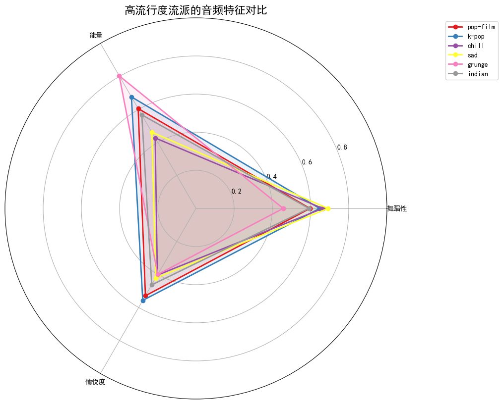

```python
# 2. 流派特征雷达图分析
# 选择几个代表性流派进行深度对比
selected_genres = genre_stats.head(6).index.tolist()  # 选择流行度最高的6个流派

# 准备雷达图数据
features_for_radar = ['avg_danceability', 'avg_energy', 'avg_valence']
radar_data = genre_stats.loc[selected_genres, features_for_radar]

# 创建雷达图
def create_radar_chart(data, genres, title):
    categories = ['舞蹈性', '能量', '愉悦度']
    N = len(categories)

    # 计算每个角度的值
    angles = [n / float(N) * 2 * np.pi for n in range(N)]
    angles += angles[:1]  # 闭合图形

    fig, ax = plt.subplots(figsize=(10, 10), subplot_kw=dict(projection='polar'))

    # 为每个流派绘制线条
    colors = plt.cm.Set1(np.linspace(0, 1, len(genres)))
    for i, genre in enumerate(genres):
        values = data.loc[genre].values.tolist()
        values += values[:1]  # 闭合图形
        ax.plot(angles, values, 'o-', linewidth=2, label=genre, color=colors[i])
        ax.fill(angles, values, alpha=0.1, color=colors[i])

    # 添加类别标签
    ax.set_xticks(angles[:-1])
    ax.set_xticklabels(categories)
    ax.set_ylim(0, 1)
    ax.set_yticks([0.2, 0.4, 0.6, 0.8])
    ax.grid(True)
    plt.legend(loc='upper right', bbox_to_anchor=(1.3, 1.0))
    plt.title(title, size=16, fontweight='bold', position=(0.5, 1.1))

    return fig

# 生成雷达图
radar_fig = create_radar_chart(radar_data, selected_genres, '高流行度流派的音频特征对比')
plt.savefig('genre_radar_chart.png', dpi=300, bbox_inches='tight')
plt.show()
```

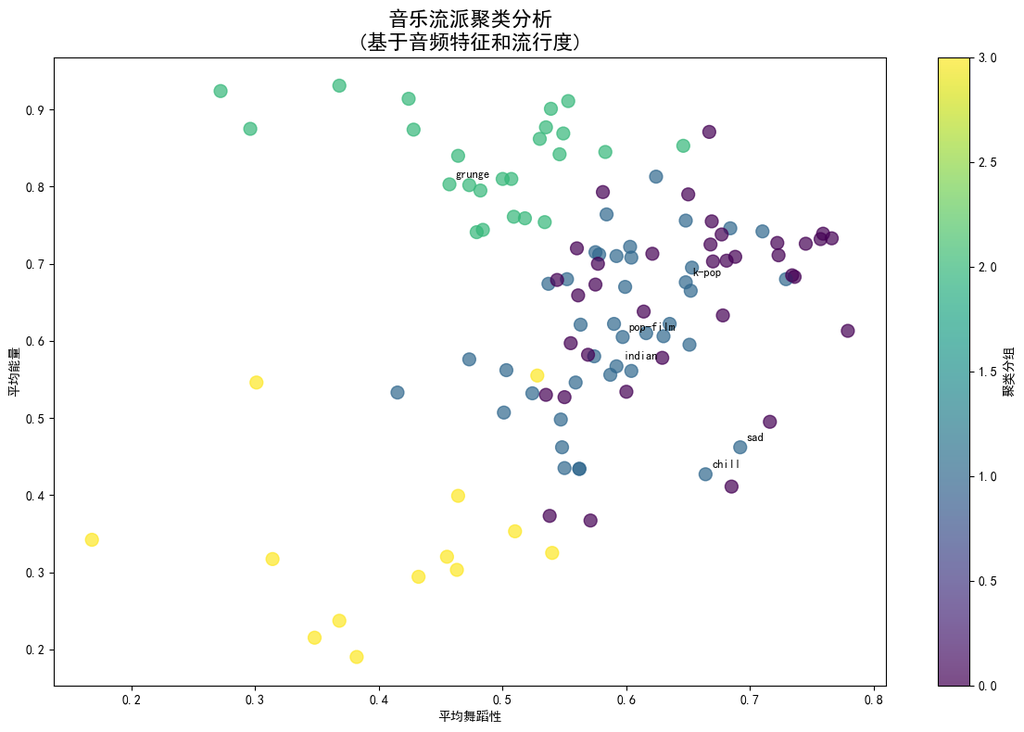

```
流派聚类分组:
聚类 0: forro, samba, hip-hop, r-n-b, synth-pop...
聚类 1: pop-film, k-pop, chill, sad, indian...
聚类 2: grunge, metal, metalcore, hard-rock, dubstep...
聚类 3: piano, ambient, sleep, show-tunes, guitar...
```

```python
# 3. 流派聚类分析
from sklearn.preprocessing import StandardScaler
from sklearn.cluster import KMeans

# 选择用于聚类的特征
cluster_features = ['avg_danceability', 'avg_energy', 'avg_valence', 'avg_tempo', 'avg_popularity']

# 标准化数据
scaler = StandardScaler()
genre_scaled = scaler.fit_transform(genre_stats[cluster_features])

# 使用K-means聚类
kmeans = KMeans(n_clusters=4, random_state=42)
genre_stats['cluster'] = kmeans.fit_predict(genre_scaled)

# 可视化聚类结果
plt.figure(figsize=(12, 8))
scatter = plt.scatter(genre_stats['avg_danceability'], genre_stats['avg_energy'],
                     c=genre_stats['cluster'], cmap='viridis', s=100, alpha=0.7)

# 标注一些代表性流派
for i, genre in enumerate(selected_genres):
    if genre in genre_stats.index:
        plt.annotate(genre,
                    (genre_stats.loc[genre, 'avg_danceability'],
                     genre_stats.loc[genre, 'avg_energy']),
                    xytext=(5, 5), textcoords='offset points',
                    fontsize=9)

plt.colorbar(scatter, label='聚类分组')
plt.xlabel('平均舞蹈性')
plt.ylabel('平均能量')
plt.title('音乐流派聚类分析\n(基于音频特征和流行度)', fontsize=16, fontweight='bold')
plt.tight_layout()
plt.savefig('genre_clustering.png', dpi=300, bbox_inches='tight')
plt.show()

print("流派聚类分组:")
for cluster_id in range(4):
    cluster_genres = genre_stats[genre_stats['cluster'] == cluster_id].index.tolist()
    print(f"聚类 {cluster_id}: {', '.join(cluster_genres[:5])}{'...' if len(cluster_genres) > 5 else ''}")
```

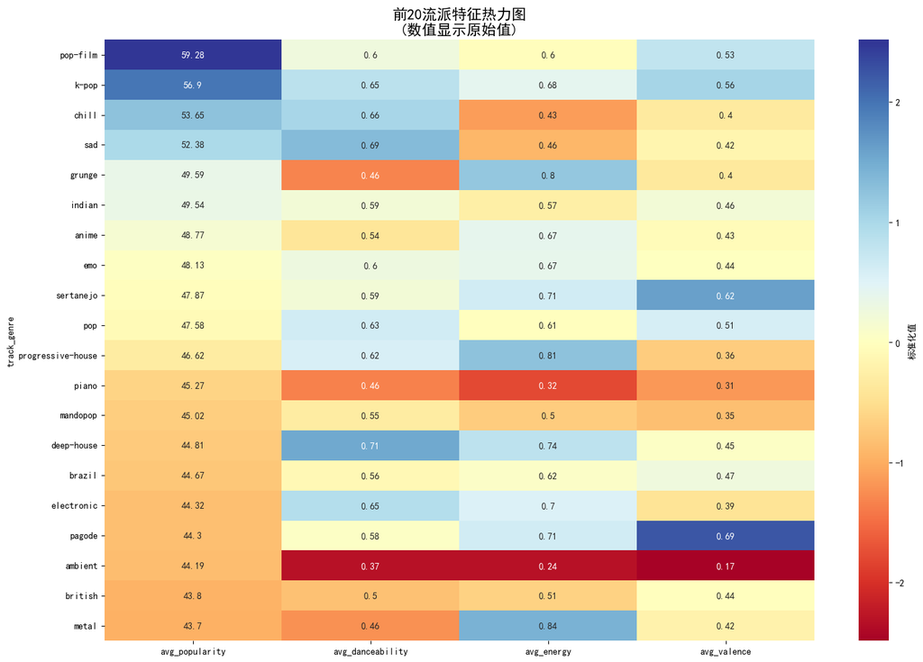

```python
# 4. 流派特征热力图
# 选择前20个流派进行详细分析
top_20_genres = genre_stats.head(20).index

# 创建流派特征热力图
plt.figure(figsize=(15, 10))
heatmap_data = genre_stats.loc[top_20_genres, ['avg_popularity', 'avg_danceability', 'avg_energy', 'avg_valence']]

# 标准化每列以便比较
heatmap_data_normalized = (heatmap_data - heatmap_data.mean()) / heatmap_data.std()

sns.heatmap(heatmap_data_normalized, annot=heatmap_data.round(2), fmt='',
            cmap='RdYlBu', center=0, cbar_kws={'label': '标准化值'})
plt.title('前20流派特征热力图\n(数值显示原始值)', fontsize=16, fontweight='bold')
plt.tight_layout()
plt.savefig('genre_heatmap.png', dpi=300, bbox_inches='tight')
plt.show()
```